# 20260507_OpeSpectral

# Spectral Flow Cytometry UMAP Analysis

We will create a UMAP from Ope’s spectral data. The purpose of this experiment is to recreate the UMAPs generated by Ope in Cafe. If we can generate similar results, this method may give us more control over the analysis.

## Library and Sample prep

install.packages(“BiocManager”)

BiocManager::install(“FlowSOM”)

```r
library(tidyverse)
library(uwot)
```

```r
library(ggplot2)
library(dplyr)
library(FlowSOM)
library(pheatmap)

data_dir <- "/Data/Input/SpectralFlow_FromOpe"

files <- list.files(
  path = data_dir,
  pattern = "\\.csv$",
  full.names = TRUE
)

files
```

```
##  [1] "/Data/Input/SpectralFlow_FromOpe/Sample1_Ctrl.csv"
##  [2] "/Data/Input/SpectralFlow_FromOpe/Sample10_CBD.csv"
##  [3] "/Data/Input/SpectralFlow_FromOpe/Sample11_CBD.csv"
##  [4] "/Data/Input/SpectralFlow_FromOpe/Sample12_CBD.csv"
##  [5] "/Data/Input/SpectralFlow_FromOpe/Sample13_CBD.csv"
##  [6] "/Data/Input/SpectralFlow_FromOpe/Sample14_CBD.csv"
##  [7] "/Data/Input/SpectralFlow_FromOpe/Sample15_CBD.csv"
##  [8] "/Data/Input/SpectralFlow_FromOpe/Sample16_CBD.csv"
##  [9] "/Data/Input/SpectralFlow_FromOpe/Sample2_Ctrl.csv"
## [10] "/Data/Input/SpectralFlow_FromOpe/Sample3_Ctrl.csv"
## [11] "/Data/Input/SpectralFlow_FromOpe/Sample4_Ctrl.csv"
## [12] "/Data/Input/SpectralFlow_FromOpe/Sample5_Ctrl.csv"
## [13] "/Data/Input/SpectralFlow_FromOpe/Sample6_Ctrl.csv"
## [14] "/Data/Input/SpectralFlow_FromOpe/Sample7_Ctrl.csv"
## [15] "/Data/Input/SpectralFlow_FromOpe/Sample8_Ctrl.csv"
## [16] "/Data/Input/SpectralFlow_FromOpe/Sample9_CBD.csv"
```

```r
length(files)
```

```
## [1] 16
```

## Spectral Flow UMAP Analysis

### Extract naming and meta data

```r
flow_df <- purrr::map_dfr(files, function(f) {

  file_base <- tools::file_path_sans_ext(basename(f))

  sample_id <- stringr::str_extract(file_base, "Sample\\d+")
  group <- stringr::str_extract(file_base, "Ctrl|CBD")

  read.csv(f, check.names = FALSE) %>%
    mutate(
      sample_id = sample_id,
      group = group,
      file_name = basename(f)
    )
})

# Check import
dim(flow_df)
```

```
## [1] 533689     13
```

```r
table(flow_df$sample_id, flow_df$group)
```

```
##
##              CBD  Ctrl
##   Sample1      0 13722
##   Sample10 43798     0
##   Sample11 29579     0
##   Sample12 33308     0
##   Sample13 43771     0
##   Sample14 42053     0
##   Sample15 39119     0
##   Sample16 25143     0
##   Sample2      0 16025
##   Sample3      0 46258
##   Sample4      0 42134
##   Sample5      0 31724
##   Sample6      0 36679
##   Sample7      0 38737
##   Sample8      0 26675
##   Sample9  24964     0
```

```r
colnames(flow_df)
```

```
##  [1] "PD1"       "CD44"      "CTLA4"     "CD3"       "CD4"       "CD62L"
##  [7] "KI67"      "CD8"       "NK11"      "FOXP3"     "sample_id" "group"
## [13] "file_name"
```

### Define markers used in panel.

We can alter this lost if we do not want a marker to define changes in our spectral data. For example, we could remove KI67 if we though its expression was not determining meaningful biology. In this case, our panel is small so we can include everything.

```r
marker_cols <- c(
   "PD1",
  "CD44",
  "CTLA4",
  "CD62L",
  "KI67",
  "FOXP3",
  "CD3",
  "CD4",
  "CD8",
  "NK11"
)


# Check that all markers exist
setdiff(marker_cols, colnames(flow_df))
```

```
## character(0)
```

### Sample QC and Transformations

```r
flow_clean <- flow_df

for (m in marker_cols) {

  low_cut  <- quantile(flow_clean[[m]], 0.01, na.rm = TRUE)
  high_cut <- quantile(flow_clean[[m]], 0.99, na.rm = TRUE)

  flow_clean[[m]] <- pmin(
    pmax(flow_clean[[m]], low_cut),
    high_cut
  )
}
```

Transforming the data is key when a lot of the difference in biology is masked by a non-linear scale. See the below graphs for examples. Changing the cofactor alters the transformation.

```r
flow_trans <- flow_clean

cofactor <- 50

flow_trans[marker_cols] <- asinh(
  flow_trans[marker_cols] / cofactor
)
```

Non-transformed data. See how these graphs have extremely harsh peaks.

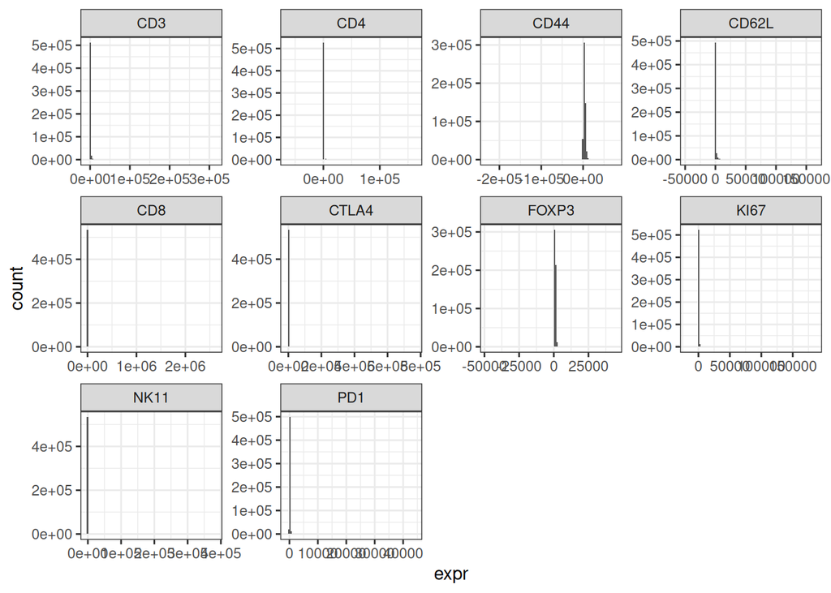

```r
flow_df %>%
  select(all_of(marker_cols)) %>%
  pivot_longer(
    everything(),
    names_to = "marker",
    values_to = "expr"
  ) %>%
  ggplot(aes(expr)) +
  geom_histogram(bins = 100) +
  facet_wrap(~marker, scales = "free") +
  theme_bw()
```

Transformed data shows meaningful differences in marker expression.

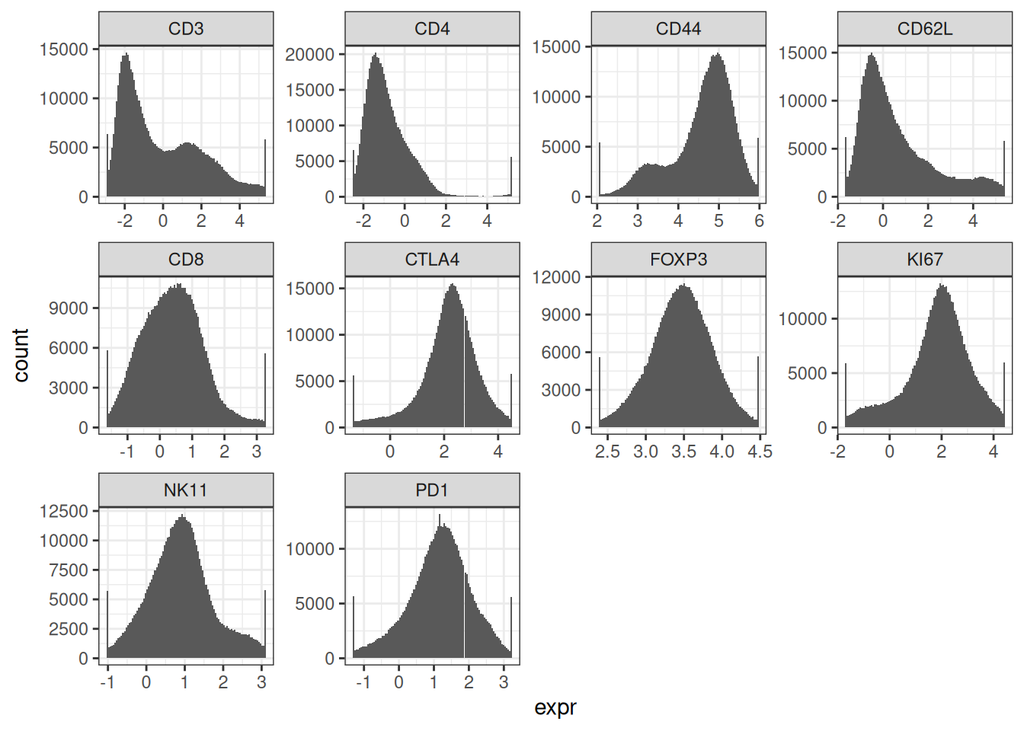

```r
flow_trans %>%
  select(all_of(marker_cols)) %>%
  pivot_longer(everything(),
               names_to = "marker",
               values_to = "expr") %>%
  ggplot(aes(expr)) +
  geom_histogram(bins = 100) +
  facet_wrap(~marker, scales = "free") +
  theme_bw()
```

```r
flow_trans %>%
  count(sample_id, group)
```

```
##    sample_id group     n
## 1    Sample1  Ctrl 13722
## 2   Sample10   CBD 43798
## 3   Sample11   CBD 29579
## 4   Sample12   CBD 33308
## 5   Sample13   CBD 43771
## 6   Sample14   CBD 42053
## 7   Sample15   CBD 39119
## 8   Sample16   CBD 25143
## 9    Sample2  Ctrl 16025
## 10   Sample3  Ctrl 46258
## 11   Sample4  Ctrl 42134
## 12   Sample5  Ctrl 31724
## 13   Sample6  Ctrl 36679
## 14   Sample7  Ctrl 38737
## 15   Sample8  Ctrl 26675
## 16   Sample9   CBD 24964
```

### Creating UMAP and downsampling

No PCA is necessary because we only have 10 markers. If we had 20-30 markers then we could perform a PCA.

In this case we used 5000 cells.

```r
set.seed(123)

cells_per_sample <- 5000

flow_ds <- flow_trans %>%
  group_by(sample_id) %>%
  group_modify(~ {

    n_keep <- min(cells_per_sample, nrow(.x))

    slice_sample(.x, n = n_keep)

  }) %>%
  ungroup()
```

```r
flow_ds %>%
  count(sample_id, group)
```

```
## # A tibble: 16 × 3
##    sample_id group     n
##    <chr>     <chr> <int>
##  1 Sample1   Ctrl   5000
##  2 Sample10  CBD    5000
##  3 Sample11  CBD    5000
##  4 Sample12  CBD    5000
##  5 Sample13  CBD    5000
##  6 Sample14  CBD    5000
##  7 Sample15  CBD    5000
##  8 Sample16  CBD    5000
##  9 Sample2   Ctrl   5000
## 10 Sample3   Ctrl   5000
## 11 Sample4   Ctrl   5000
## 12 Sample5   Ctrl   5000
## 13 Sample6   Ctrl   5000
## 14 Sample7   Ctrl   5000
## 15 Sample8   Ctrl   5000
## 16 Sample9   CBD    5000
```

### Set UMAP parameters

```r
set.seed(123)

umap_mat <- uwot::umap(
  flow_ds[, marker_cols],
  n_neighbors = 30,
  min_dist = 0.15,
  metric = "euclidean",
  verbose = TRUE
)
```

```
## 16:01:15 Converting dataframe to numerical matrix
```

```r
flow_umap <- flow_ds %>%
  mutate(
    UMAP_1 = umap_mat[,1],
    UMAP_2 = umap_mat[,2]
  )
```

By group

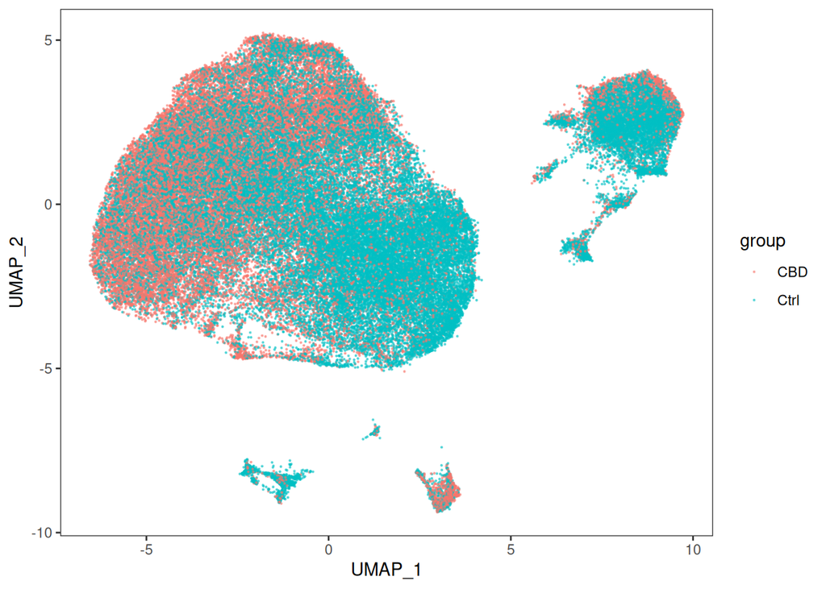

```r
ggplot(flow_umap,
       aes(UMAP_1, UMAP_2, color = group)) +
  geom_point(
    size = 0.15,
    alpha = 0.5
  ) +
  theme_bw() +
  theme(panel.grid = element_blank())
```

By sample

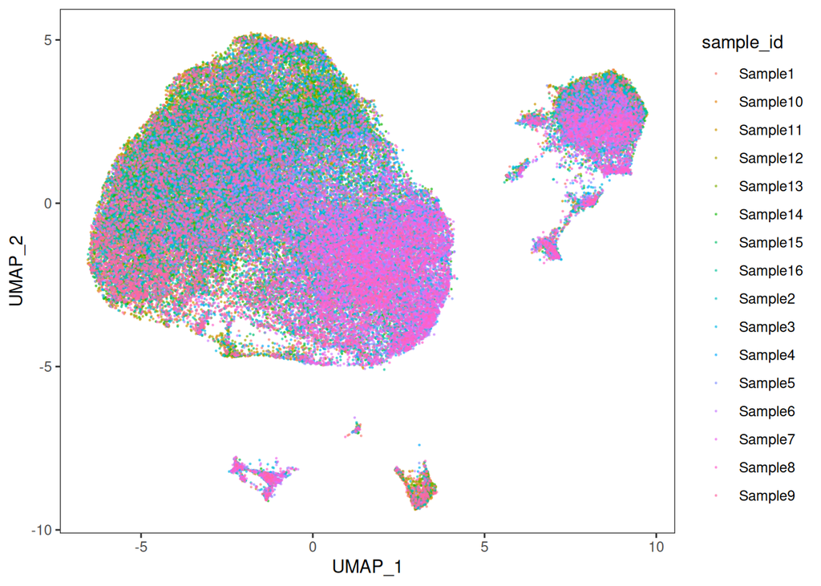

```r
ggplot(flow_umap,
       aes(UMAP_1, UMAP_2, color = sample_id)) +
  geom_point(
    size = 0.15,
    alpha = 0.5
  ) +
  theme_bw() +
  theme(panel.grid = element_blank())
```

By marker

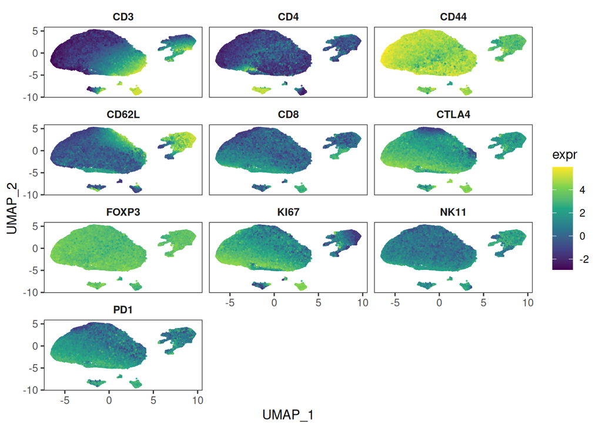

```r
flow_umap %>%
  select(
    UMAP_1,
    UMAP_2,
    all_of(marker_cols)
  ) %>%
  pivot_longer(
    cols = all_of(marker_cols),
    names_to = "marker",
    values_to = "expr"
  ) %>%
  ggplot(aes(UMAP_1, UMAP_2, color = expr)) +
  geom_point(
    size = 0.15,
    alpha = 0.7
  ) +
  scale_color_viridis_c() +
  facet_wrap(~marker, ncol = 3) +
  theme_bw() +
  theme(
    panel.grid = element_blank(),
    strip.background = element_blank(),
    strip.text = element_text(face = "bold")
  )
```

### FlowSOM clustering

```r
# make numeric matrix for FlowSOM
fsom_input <- flow_ds %>%
  dplyr::select(all_of(marker_cols)) %>%
  as.data.frame()

fsom_input[] <- lapply(fsom_input, as.numeric)

fsom_mat <- as.matrix(fsom_input)
```

```r
set.seed(123)

fsom <- FlowSOM::FlowSOM(
  fsom_mat,
  colsToUse = seq_len(ncol(fsom_mat)),
  xdim = 10,
  ydim = 10,
  nClus = 6,
  scale = FALSE
)
```

```r
# Each cell's SOM node
cell_to_node <- fsom$map$mapping[, 1]

# Each cell's metacluster
flow_umap$cluster <- factor(fsom$metaclustering[cell_to_node])
```

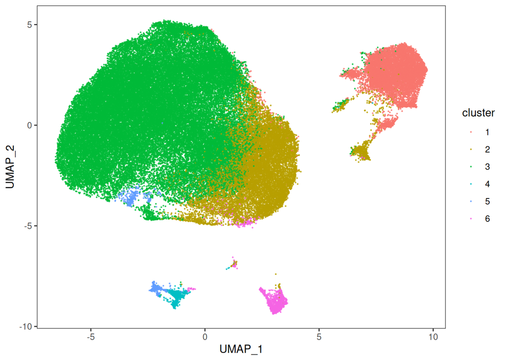

```r
ggplot(flow_umap,
       aes(UMAP_1, UMAP_2, color = cluster)) +
  geom_point(size = 0.15, alpha = 0.7) +
  theme_bw() +
  theme(panel.grid = element_blank())
```

```r
cluster_summary <- flow_umap %>%
  group_by(cluster) %>%
  summarise(
    across(all_of(marker_cols), median),
    .groups = "drop"
  )

cluster_mat <- cluster_summary %>%
  column_to_rownames("cluster") %>%
  as.matrix()
```

```r
cluster_mat_scaled <- scale(cluster_mat)
```

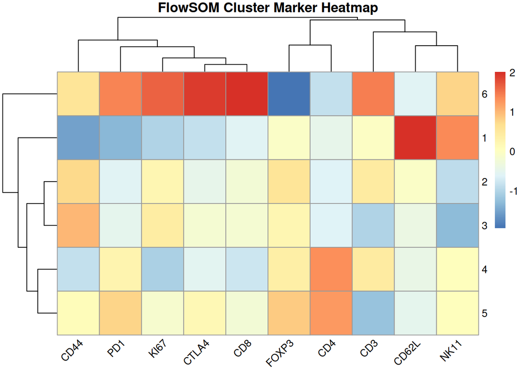

```r
pheatmap(
  cluster_mat_scaled,
  cluster_rows = TRUE,
  cluster_cols = TRUE,
  fontsize_row = 10,
  fontsize_col = 10,
  angle_col = 45,
  main = "FlowSOM Cluster Marker Heatmap"
)
```